# Permutation tests

DSCI 632: Statistics for Data Science

Peter Ralph, University of Oregon

# Permutation tests

```
##
##  Welch Two Sample t-test
##
## data:  airbnb$price[airbnb$instant_bookable] and airbnb$price[!airbnb$instant_bookable]
## t = 3.6482, df = 5039.8, p-value = 0.0002667
## alternative hypothesis: true difference in means is not equal to 0
## 95 percent confidence interval:
##   4.475555 14.872518
## sample estimates:
## mean of x mean of y
##  124.6409  114.9668
```

**But,** the $t$ test relies on *Normality* (a little). Is the distribution of AirBnB prices too “weird”? How can we be sure?

Methods:

1. Remove the big values and try again.
2. Use a nonparametric test.

## The permutation test

*Observation:* **If** there was no meaningful difference in prices between “instant bookable” and not, **then randomly shuffling that label** won’t change anything.

Strategy:

1. Shuffle the `instant_bookable` column.
2. Compute the difference in means.
3. Repeat, many times.
4. Compare: the $p$-value is the proportion of “shuffled” values more extreme than observed.

*Why* is this a $p$-value? For what hypothesis?

## Shuffle once

```r
fake_is_instant <- sample(airbnb$instant_bookable)
(mean(airbnb$price[fake_is_instant], na.rm=TRUE) -
                mean(airbnb$price[!fake_is_instant], na.rm=TRUE))
```

```
## [1] 2.837541
```

## Many times

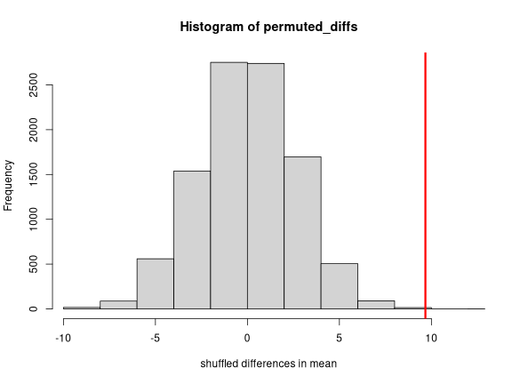

```r
real_diff <- (mean(airbnb$price[airbnb$instant_bookable], na.rm=TRUE)
               - mean(airbnb$price[!airbnb$instant_bookable], na.rm=TRUE))
permuted_diffs <- replicate(10000, {
        fake_is_instant <- sample(airbnb$instant_bookable)
        (mean(airbnb$price[fake_is_instant], na.rm=TRUE)
             - mean(airbnb$price[!fake_is_instant], na.rm=TRUE))
   } )
hist(permuted_diffs, xlab="shuffled differences in mean", xlim=range(c(permuted_diffs, real_diff)))
abline(v=real_diff, col='red', lwd=3)
```

## How surprising was the real value?

```r
mean(abs(permuted_diffs) > abs(real_diff))
```

```
## [1] 3e-04
```

> The difference in price between instant bookable and not instant bookable is highly statistically significant ($p \approx 0.0003$, permutation test).

# Mammals big and small

**Question:** do herbivores tend to be bigger than carnivores?

Let’s have a look, in the PanTHERIA data:

```r
source("../datasets/PanTHERIA/read_pantheria.R")
pantheria <- read_pantheria("../datasets/PanTHERIA")
head(pantheria)
```

```
##          Order    Family   Genus     Species            Binomial ActivityCycle AdultBodyMass_g AdultForearmLen_mm AdultHeadBodyLen_mm AgeatEyeOpening_d AgeatFirstBirth_d BasalMetRate_mLO2hr BasalMetRateMass_g
## 1 Artiodactyla Camelidae Camelus dromedarius Camelus dromedarius       diurnal       492714.47                 NA                  NA                NA           1651.62             40293.0             407000
## 2    Carnivora   Canidae   Canis     adustus       Canis adustus     nocturnal        10392.49                 NA              745.32                NA                NA                  NA                 NA
## 3    Carnivora   Canidae   Canis      aureus        Canis aureus   crepuscular         9658.70                 NA              827.53              7.50                NA                  NA                 NA
## 4    Carnivora   Canidae   Canis     latrans       Canis latrans   crepuscular        11989.10                 NA              872.39             11.94            365.00              3699.0              10450
## 5    Carnivora   Canidae   Canis       lupus         Canis lupus   crepuscular        31756.51                 NA             1055.00             14.01            547.50             11254.2              33100
## 6 Artiodactyla   Bovidae     Bos   frontalis       Bos frontalis   crepuscular       800143.05                 NA             2700.00                NA                NA                  NA                 NA
##   DietBreadth DispersalAge_d GestationLen_d HabitatBreadth HomeRange_km2 HomeRange_Indiv_km2 InterbirthInterval_d LitterSize LittersPerYear MaxLongevity_m NeonateBodyMass_g NeonateHeadBodyLen_mm
## 1           3             NA         386.51              1        196.32                  NA               614.41       0.98              1          480.0          36751.19                    NA
## 2           6         329.99          65.00              1          1.01                1.01                   NA       4.50             NA          137.0                NA                    NA
## 3           6             NA          61.24              1          2.95                3.13               365.00       3.74             NA          192.0            211.82                    NA
## 4           1         255.00          61.74              1         18.88               19.91               365.00       5.72             NA          262.0            200.01                    NA
## 5           1         180.00          63.50              1        159.86               43.13               365.00       4.98              2          354.0            412.31                    NA
## 6           3             NA         273.75             NA            NA                  NA               403.02       1.22              1          314.4          22977.05                    NA
##   PopulationDensity_n/km2 PopulationGrpSize SexualMaturityAge_d SocialGrpSize TeatNumber Terrestriality TrophicLevel WeaningAge_d WeaningBodyMass_g WeaningHeadBodyLen_mm
## 1                    0.98                11             1947.94            10         NA      fossorial    herbivore       389.38                NA                    NA
## 2                    0.74                NA              249.88            NA          8      fossorial     omnivore        52.89                NA                    NA
## 3                    0.22                NA              371.23            NA          8      fossorial     omnivore        61.30                NA                    NA
## 4                    0.25                NA              372.90            NA          8      fossorial    carnivore        43.71                NA                    NA
## 5                    0.01                NA              679.37            NA          9      fossorial    carnivore        44.82                NA                    NA
## 6                    0.54                NA              610.97            40         NA           <NA>    herbivore       186.67                NA                    NA
```

Let’s have a look:

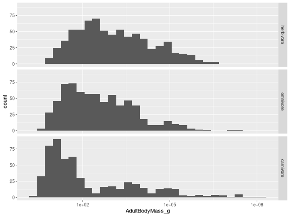

```r
pantheria |> filter(!is.na(TrophicLevel)) |>
    ggplot(aes(x=AdultBodyMass_g)) +
        geom_histogram(bins=30) +
        scale_x_continuous(transform="log10") +
        facet_grid(TrophicLevel~.)
```

## Your turn

*Do herbivores tend to be bigger than carnivores?*

0. Read in the data, and subset to only `TrophicLevel %in% c("herbivore", "carnivore")`.
1. Compute a summary that answers this question.
2. Compute the same summary after shuffling the `TrophicLevel` column up lots of times.
3. Find the proportion of those shuffles that got a difference as big as you did in (1).
4. Do you see any problems with this test?

## in class

```r
diff_means <- function (body_mass, trophic_level) {
    c_means <-  mean(body_mass[trophic_level == "carnivore"], na.rm=TRUE)
    h_means <- mean(body_mass[trophic_level == "herbivore"], na.rm=TRUE)
    return(c_means - h_means)
}
# true value
obs_value <- diff_means(log10(pantheria$AdultBodyMass_g), pantheria$TrophicLevel)

# one shuffled value
shuf_trophic_level <- sample(pantheria$TrophicLevel)
diff_means(log10(pantheria$AdultBodyMass_g), shuf_trophic_level)
```

```
## [1] -0.02773901
```

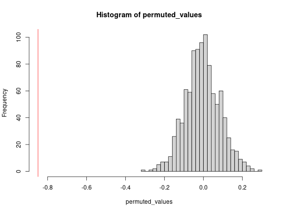

```r
permuted_values <- replicate(1000, {
    shuf_trophic_level <- sample(pantheria$TrophicLevel)
    diff_means(log10(pantheria$AdultBodyMass_g), shuf_trophic_level)
})
hist(permuted_values, breaks=40, xlim=range(obs_value, permuted_values))
abline(v=obs_value, col='red')
```

```r
# The p-value is "less than 1/1000" by a two-sided permutation test.
```

The problem: Permutation tests do not magically get rid of confounding variables.

```r
with(pantheria, table(Order, TrophicLevel))
```

```
##                   TrophicLevel
## Order              herbivore omnivore carnivore
##   Afrosoricida             0        4        27
##   Artiodactyla           139       25         0
##   Carnivora                7      114       109
##   Cetacea                  0        2        49
##   Chiroptera             114       64       274
##   Cingulata                0       13         7
##   Dasyuromorphia           0       10        16
##   Dermoptera               2        0         0
##   Didelphimorphia          0       24        16
##   Diprotodontia           59       23         0
##   Erinaceomorpha           0       10         9
##   Hyracoidea               4        0         0
##   Lagomorpha              41        0         0
##   Macroscelidea            0        4         5
##   Microbiotheria           0        1         0
##   Monotremata              0        0         3
##   Notoryctemorphia         0        1         0
##   Paucituberculata         0        3         3
##   Peramelemorphia          1       14         0
##   Perissodactyla          13        1         0
##   Pholidota                0        0         4
##   Pilosa                   3        2         4
##   Primates                69      109         0
##   Proboscidea              3        0         0
##   Rodentia               327      268        45
##   Scandentia               0       12         0
##   Sirenia                  1        3         0
##   Soricomorpha             0       32        67
##   Tubulidentata            0        0         1
```

What do we *really* want to know? The next plan:

1. Find pairs of species in the same family for which one is a carnivore and the other an herbivore.
2. Compute within each pair **(some statistic)** comparing carnivore to herbivore size, and average these (the test statistic).
3. *Randomly reassign* “trophic level” within families many times, recomputing this statistic.
4. The $p$-value is the proportion of shuffled statistics greater than the observed statistic.

## In class

Which families have both an herbivore and a carnivore

```r
table(
    pantheria$Family,
    pantheria$TrophicLevel
)
```

```
##
##                       herbivore omnivore carnivore
##   Abrocomidae                 0        0         0
##   Acrobatidae                 0        2         0
##   Ailuridae                   1        0         0
##   Anomaluridae                2        0         0
##   Antilocapridae              1        0         0
##   Aotidae                     1        7         0
##   Aplodontiidae               1        0         0
##   Atelidae                   10        4         0
##   Balaenidae                  0        0         3
##   Balaenopteridae             0        0         6
##   Bathyergidae                7        1         0
##   Bovidae                    95        9         0
##   Bradypodidae                2        1         0
##   Burramyidae                 0        4         0
##   Caenolestidae               0        3         3
##   Calomyscidae                0        0         0
##   Camelidae                   4        0         0
##   Canidae                     0       17        15
##   Capromyidae                 4        8         0
##   Castoridae                  2        0         0
##   Caviidae                   10        0         0
##   Cebidae                     0       27         0
##   Cercopithecidae            35       24         0
##   Cervidae                   25        3         0
##   Chaeropodidae               0        1         0
##   Cheirogaleidae              0        8         0
##   Chinchillidae               4        0         0
##   Chrysochloridae             0        2        15
##   Craseonycteridae            0        0         1
##   Cricetidae                 43       74        27
##   Ctenodactylidae             4        0         0
##   Ctenomyidae                42        0         0
##   Cuniculidae                 2        0         0
##   Cyclopedidae                0        0         1
##   Cynocephalidae              2        0         0
##   Dasypodidae                 0       13         7
##   Dasyproctidae              12        0         0
##   Dasyuridae                  0       10        15
```

[output cut: 100 more lines]

```
##   Tarsipedidae                1        0         0
##   Tayassuidae                 1        2         0
##   Tenrecidae                  0        2        12
##   Thryonomyidae               1        0         0
##   Thylacinidae                0        0         0
##   Thylacomyidae               0        2         0
##   Thyropteridae               0        0         1
##   Tragulidae                  3        0         0
##   Trichechidae                1        2         0
##   Tupaiidae                   0       11         0
##   Ursidae                     4        4         0
##   Vespertilionidae            0        0        93
##   Viverridae                  1       22         2
##   Vombatidae                  3        0         0
##   Ziphiidae                   0        0         7
```

```r
has_both <- ft[,"herbivore"] > 0 & ft[,"carnivore"] > 0
```

[output not shown]

```r
families <- rownames(ft)[has_both]
```

[output not shown]

```r
fam <- "Cricetidae"
means <- pantheria |> filter(Family == fam) |>
    summarise(meanlogsize = mean(log(AdultBodyMass_g), na.rm=TRUE), .by=TrophicLevel)
herb_index <- which(means$TrophicLevel == "herbivore")
stopifnot(length(herb_index) == 1)
carn_index <- which(means$TrophicLevel == "carnivore")
stopifnot(length(carn_index) == 1)
obs_value <- means$meanlogsize[herb_index] -  means$meanlogsize[carn_index]
obs_value
```

```
## [1] 0.1190104
```

All the families:

```r
obs_means <- rep(NA, length(families))
```

[output not shown]

```r
names(obs_means) <- families
```

[output not shown]

```r
for (fam in families) {
    means <- pantheria |> filter(Family == fam) |>
        summarise(meanlogsize = mean(log(AdultBodyMass_g), na.rm=TRUE), .by=TrophicLevel)
    herb_index <- which(means$TrophicLevel == "herbivore")
    stopifnot(length(herb_index) == 1)
    carn_index <- which(means$TrophicLevel == "carnivore")
    stopifnot(length(carn_index) == 1)
    obs_means[fam] <- means$meanlogsize[herb_index] -  means$meanlogsize[carn_index]
}
```

[output not shown]

DRY = Don’t Repeat Yourself WET = Write Everything Twice

Shuffled:

```r
nreps <- 2000
shuf_means <- matrix(NA, nrow=nreps, ncol=length(families))
```

[output not shown]

```r
colnames(shuf_means) <- families
```

[output not shown]

```r
for (fam in families) {
    for (k in 1:nreps) {
        means <- pantheria |> filter(Family == fam & !is.na(AdultBodyMass_g)) |>
            mutate(TrophicLevel = sample(TrophicLevel)) |>
            summarise(meanlogsize = mean(log(AdultBodyMass_g), na.rm=TRUE), .by=TrophicLevel)
        herb_index <- which(means$TrophicLevel == "herbivore")
        stopifnot(length(herb_index) == 1)
        carn_index <- which(means$TrophicLevel == "carnivore")
        stopifnot(length(carn_index) == 1)
        shuf_means[k, fam] <- means$meanlogsize[herb_index] -  means$meanlogsize[carn_index]
    }
}
```

[output not shown]

```r
shuf_means
```

[output not shown]

Look at results:

```r
obs_df <- data.frame(
    Family = names(obs_means),
    value = obs_means)
)

shuf_means |> as.data.frame() |> pivot_longer(cols=everything(), names_to="Family") |>
    ggplot(aes(x=value)) + geom_histogram(bins=40) + facet_grid(Family ~ .) +
    geom_vline(aes(xintercept=value), data=obs_df)
```

[output not shown]

Get $p$-values, first by family and then overall:

```r
# by family:
family_p_vals <- colMeans(shuf_means > obs_means)
```

[output not shown]

```r
# overall
p_val <- mean( rowMeans(shuf_means) > mean(obs_means) )
```

[output not shown]

```r
c(family_p_vals , c(overall=p_val))
```

[output not shown]